# Análisis Bayesiano de Datos - Tarea 1

Rodrigo Fritz

Febrero 17, 2022

### Familias Conjugadas

Si $P(\theta)\in\mathcal{F} \Rightarrow P(\theta|S_m)\in\mathcal{F}$, donde $S_m = \{x_1, \dots, x_m\}$ es una muestra de tamaño $m$ y nuestra estadística suficiente es $t_m = \sum\limits_{j=1}^m x_j$.

En clase llegamos a que
$$P(\theta|S_m) \propto \text{Gamma}(\theta|\alpha + m, \beta + t_m)$$

### 1. La Gamma

$$\mathbb{P}(x|\theta_0) = \theta_0 e^{-\theta_0x}$$

```r
m = 1000 #tamaño de muestra
theta = 2.71
x = rexp(m, theta)
mean(x)
```

```
## [1] 0.3712172
```

```r
sum(x)
```

```
## [1] 371.2172
```

El $n$-ésimo momento de la Gamma está dado por
$$E(\theta^n|\alpha,\beta) = \left(\frac{1}{\beta}\right)^n\ \frac{\Gamma(\alpha + n)}{\Gamma(\alpha)}$$
pero para $n=2$, esto es simplemente
$$E(\theta^2|\alpha,\beta) = V(\theta) + E(\theta)^2 = \frac{\alpha}{\beta^2} + \left(\frac{\alpha}{\beta}\right)^2 = \frac{\alpha(1+\alpha)}{\beta^2}$$

```r
alpha = 1.02 + m
beta = 0.47 + sum(x)
n_a = alpha*(alpha+1)/beta^2
n_a
```

```
## [1] 7.260455
```

### 2. Aproximación Normal

$P_G(\theta|S_m) \approx N(\theta|\hat{\theta}_m, h_m)$, donde el estimador máximo verosímil $\hat{\theta}_m$ se obtiene de maximizar la log-verosimilitud
$$l(\theta) = m\log\theta - \theta\sum_{j=1}^m x_j$$
lo que resulta en $\hat{\theta}_m = \dfrac{1}{\bar{x}_m}$, y en la precisión $h_m = -\dfrac{\partial^2}{\partial\theta^2}l(\theta)|_{\hat{\theta}_m} = m\bar{x}_m^2$, i.e. $\sigma^2 = \dfrac{1}{m\bar{x}_m^2}$, por lo que
$$P_G(\theta|S_m) \approx N\left(\theta\ \Bigg|\frac{1}{\bar{x}_m},\ \frac{1}{m\bar{x}_m^2}\right)$$
así, el 2do momento de $\theta$ se aproxima con
$$E(\theta^2) = \mu^2 + \sigma^2 = \frac{1}{\bar{x}_m^2} + \frac{1}{m\bar{x}_m^2}$$

```r
1/mean(x)^2 + 1/(m*mean(x)^2)
```

```
## [1] 7.264033
```

[figure not shown]

La media de estas Normales es

```r
mean(th_nrm)
```

[output not shown]

```
## [1] 7.260225
```

### 3. Aproximación de Laplace

$$E[\theta^2|\text{Laplace}] \approx (\theta_m^*)^2$$

$$\theta_m^* \propto \underset{\Theta}{\arg\max}\left\{-\frac{1}{m}\log \mathbb{P}(\theta|S_m)\right\}$$
Como
$$\mathbb{P}(\theta|S_m) \propto \text{Ga}(\theta|\alpha,\beta)$$
se tiene que
$$\log \mathbb{P}(\theta|S_m) \propto (\alpha-1)\log\theta - \beta\theta.$$
Derivando con respecto a $\theta$ e igualando a cero, se obtiene que el máximo es

$$\theta^*_m = \frac{\alpha-1}{\beta} = \frac{\alpha_0+m-1}{\beta_0 + t_m}$$

```r
theta_star = ((alpha+m)-1)/(beta + sum(x))
theta_star^2
```

```
## [1] 7.247742
```

### 4. 5,000 repeticiones de Laplace

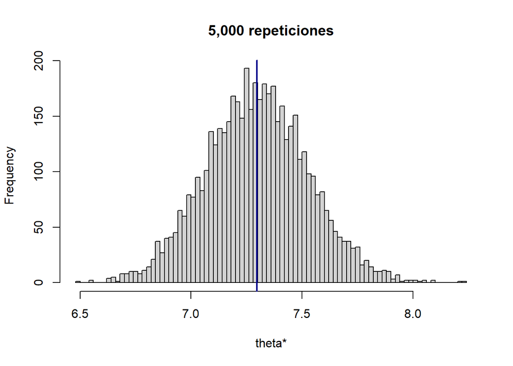

```r
vec = rep(NA)
for(i in 1:5000){
  x = rexp(m, theta)
  theta_star = ((alpha+m)-1)/(beta + sum(x))
  vec[i] = theta_star^2
}
hist(vec, breaks = 100, main='5,000 repeticiones', xlab='theta*')
abline(v = mean(vec), col = 'darkblue', lwd = 2)
```

```r
mean(vec)
```

```
## [1] 7.296688
```

### 5. Aproximar con la forma exponencial completa

Tenemos que en la forma exponencial completa

$$h_N(\theta) = -\frac{1}{m}\log[\theta^2\mathbb{P}(\theta|S_m)]$$
$$h_D(\theta) = -\frac{1}{m}\log[\mathbb{P}(\theta|S_m)]$$

En este caso

$$h_D^* = -\frac{\partial^2}{\partial\theta^2} h_D(\theta)
= \frac{\alpha-1}{(\theta_m^*)^2}
= \frac{\beta^2}{\alpha-1}$$

y

$$\frac{\partial}{\partial\theta} h_N(\theta)
= \frac{\alpha+1}{\theta} - \beta$$

y entonces

$$\theta_N^* = \frac{\alpha+1}{\beta}$$

y

$$h_N^* = -\frac{\partial^2}{\partial\theta^2} h_N(\theta)
= \frac{\alpha+1}{\theta^2}
= \frac{(\alpha+1)\beta^2}{(\alpha-1)^2}$$

por lo tanto

$$\left(\frac{h_D^*}{h_N^*}\right)^{1/2}(\theta_N^*)^2 = \left[\frac{\beta^2}{\alpha-1} \frac{(\alpha-1)^2}{(\alpha+1)\beta^2}\right]^{1/2} \left(\frac{\alpha+1}{\beta}\right)^2
= \frac{(\alpha-1)^{1/2}(\alpha+1)^{3/2}}{\beta^2}$$

```r
( (alpha+m-1)^(1/2) * (alpha+m+1)^(3/2) ) / (beta + sum(x))^2
```

```
## [1] 7.380432
```

Me parece que $\mathbb{P}(S_m|\theta_N^*)\mathbb{P}(\theta_N^*)$ ya incluye a $(\theta_N^*)^2$, y aquí estoy considerando que
$$\mathbb{P}(S_m|\theta_N^*)\mathbb{P}(\theta_N^*) = \mathbb{P}(S_m|\theta_D^*)\mathbb{P}(\theta_D^*)$$

## Conclusión

Estas fueron las diferencias porcentuales:

Normal

```r
abs( 1/mean(x)^2 + 1/(m*mean(x)^2) - n_a ) / n_a * 100
```

```
## [1] 3.452213
```

Laplace

```r
abs(theta_star^2 - n_a) / n_a * 100
```

```
## [1] 1.500185
```

5,000 repeticiones

```r
abs(mean(vec) - n_a) / n_a * 100
```

```
## [1] 0.4990448
```

## $n_a$ con repeticiones

Haciendo 100,000 repeticiones vemos que

[figure not shown]

$n_a$ converge a

```r
mean(vec)
```

```
## [1] 7.369194
```